# MLR_Housing

### Housing Case Study

###### Problem : To optimise Sale price of the House

Problem Statement:

Consider a real estate company that has a dataset containing the prices of properties in the City region. It wishes to use the data to optimise the sale prices of the properties based on important factors such as area, bedrooms, parking, etc.

Essentially, the company wants —

- To identify the variables affecting house prices, e.g. area, number of rooms, bathrooms, etc.
- To create a linear model that quantitatively relates house prices with variables such as number of rooms, area, number of bathrooms, etc.
- To know the accuracy of the model, i.e. how well these variables can predict house prices.

### Technique : Multiple Linear Regressions

#### Assumptions of Linear Regression :

1. The regression model is linear in parameters.
2. The mean of residuals is zero.
3. Homoscedasticity of residuals or equal variance.
4. No autocorrelation of residuals. ...
5. The X variables and residuals are uncorrelated.
6. The variability in X values is positive.
7. The regression model is correctly specified.
8. No perfect multicollinearity.
9. Normality of residuals

##### Note : Most of the assumptions are followed by the model which are show in the plots

### Importing & Understanding Data

```python
## Libraries
import pandas as pd
from pandas.plotting import scatter_matrix
import numpy as np
from sklearn.model_selection import train_test_split as tts
import statsmodels.api as sm
import matplotlib.pylab as plt
import seaborn as sb
%matplotlib inline
from sklearn import metrics
```

```python
## Importing Housing.csv
house_d = pd.read_csv('Housing.csv')
```

```python
## Looking at 1st 5 Rows
house_d.head()
```

|  | price | area | bedrooms | bathrooms | stories | mainroad | guestroom | basement | hotwaterheating | airconditioning | parking | prefarea | furnishingstatus |
| --- | --- | --- | --- | --- | --- | --- | --- | --- | --- | --- | --- | --- | --- |
| 0 | 13300000 | 7420 | 4 | 2 | 3 | yes | no | no | no | yes | 2 | yes | furnished |
| 1 | 12250000 | 8960 | 4 | 4 | 4 | yes | no | no | no | yes | 3 | no | furnished |
| 2 | 12250000 | 9960 | 3 | 2 | 2 | yes | no | yes | no | no | 2 | yes | semi-furnished |
| 3 | 12215000 | 7500 | 4 | 2 | 2 | yes | no | yes | no | yes | 3 | yes | furnished |
| 4 | 11410000 | 7420 | 4 | 1 | 2 | yes | yes | yes | no | yes | 2 | no | furnished |

```python
## Looking at last 5 Riws
house_d.tail()
```

|  | price | area | bedrooms | bathrooms | stories | mainroad | guestroom | basement | hotwaterheating | airconditioning | parking | prefarea | furnishingstatus |
| --- | --- | --- | --- | --- | --- | --- | --- | --- | --- | --- | --- | --- | --- |
| 540 | 1820000 | 3000 | 2 | 1 | 1 | yes | no | yes | no | no | 2 | no | unfurnished |
| 541 | 1767150 | 2400 | 3 | 1 | 1 | no | no | no | no | no | 0 | no | semi-furnished |
| 542 | 1750000 | 3620 | 2 | 1 | 1 | yes | no | no | no | no | 0 | no | unfurnished |
| 543 | 1750000 | 2910 | 3 | 1 | 1 | no | no | no | no | no | 0 | no | furnished |
| 544 | 1750000 | 3850 | 3 | 1 | 2 | yes | no | no | no | no | 0 | no | unfurnished |

```python
house_d.shape
```

```
(545, 13)
```

```python
# What type of values are stored in the columns?
house_d.info()
```

```
<class 'pandas.core.frame.DataFrame'>
RangeIndex: 545 entries, 0 to 544
Data columns (total 13 columns):
price               545 non-null int64
area                545 non-null int64
bedrooms            545 non-null int64
bathrooms           545 non-null int64
stories             545 non-null int64
mainroad            545 non-null object
guestroom           545 non-null object
basement            545 non-null object
hotwaterheating     545 non-null object
airconditioning     545 non-null object
parking             545 non-null int64
prefarea            545 non-null object
furnishingstatus    545 non-null object
dtypes: int64(6), object(7)
memory usage: 40.5+ KB
```

```python
## What are the basic stats of house data
house_d.describe()
```

|  | price | area | bedrooms | bathrooms | stories | parking |
| --- | --- | --- | --- | --- | --- | --- |
| count | 5.450000e+02 | 545.000000 | 545.000000 | 545.000000 | 545.000000 | 545.000000 |
| mean | 4.766729e+06 | 5150.541284 | 2.965138 | 1.286239 | 1.805505 | 0.693578 |
| std | 1.870440e+06 | 2170.141023 | 0.738064 | 0.502470 | 0.867492 | 0.861586 |
| min | 1.750000e+06 | 1650.000000 | 1.000000 | 1.000000 | 1.000000 | 0.000000 |
| 25% | 3.430000e+06 | 3600.000000 | 2.000000 | 1.000000 | 1.000000 | 0.000000 |
| 50% | 4.340000e+06 | 4600.000000 | 3.000000 | 1.000000 | 2.000000 | 0.000000 |
| 75% | 5.740000e+06 | 6360.000000 | 3.000000 | 2.000000 | 2.000000 | 1.000000 |
| max | 1.330000e+07 | 16200.000000 | 6.000000 | 4.000000 | 4.000000 | 3.000000 |

### Data Preparation

- We can see that your dataset has many columns with values as 'Yes' or 'No'.
- We need to convert them to 1s and 0s, where 1 is a 'Yes' and 0 is a 'No'.

###### Converting Categorical variables of Yes & No's into Binary 1 & 0's respectively

```python
# (yes,no) ====> (1,0)
house_d['mainroad'] = house_d['mainroad'].map({'yes':1, 'no':0})
house_d['guestroom'] = house_d['guestroom'].map({'yes':1, 'no':0})
house_d['basement'] = house_d['basement'].map({'yes':1, 'no':0})
house_d['hotwaterheating'] = house_d['hotwaterheating'].map({'yes':1, 'no':0})
house_d['airconditioning'] = house_d['airconditioning'].map({'yes':1, 'no':0})
house_d['prefarea'] = house_d['prefarea'].map({'yes':1, 'no':0})
```

```python
## now let's see the head
house_d.head()
```

|  | price | area | bedrooms | bathrooms | stories | mainroad | guestroom | basement | hotwaterheating | airconditioning | parking | prefarea | furnishingstatus |
| --- | --- | --- | --- | --- | --- | --- | --- | --- | --- | --- | --- | --- | --- |
| 0 | 13300000 | 7420 | 4 | 2 | 3 | 1 | 0 | 0 | 0 | 1 | 2 | 1 | furnished |
| 1 | 12250000 | 8960 | 4 | 4 | 4 | 1 | 0 | 0 | 0 | 1 | 3 | 0 | furnished |
| 2 | 12250000 | 9960 | 3 | 2 | 2 | 1 | 0 | 1 | 0 | 0 | 2 | 1 | semi-furnished |
| 3 | 12215000 | 7500 | 4 | 2 | 2 | 1 | 0 | 1 | 0 | 1 | 3 | 1 | furnished |
| 4 | 11410000 | 7420 | 4 | 1 | 2 | 1 | 1 | 1 | 0 | 1 | 2 | 0 | furnished |

The variable 'furnishingstatus' had three levels. We need to convert it to integer.

###### now we will do categorical to integer conversion for 'furnishedstatus' variable but we can't do it like 0,1,2 as it will make numbers compare with each other. so, we will do it using dummies

```python
## creating dummy variables for 'furnishingstatus'
status = pd.get_dummies(house_d['furnishingstatus'])
```

```python
status.head()
# The result has created three variables that are not needed.
```

|  | furnished | semi-furnished | unfurnished |
| --- | --- | --- | --- |
| 0 | 1 | 0 | 0 |
| 1 | 1 | 0 | 0 |
| 2 | 0 | 1 | 0 |
| 3 | 1 | 0 | 0 |
| 4 | 1 | 0 | 0 |

```python
# we don't need 3 columns as we can get the status of any one column by droping any 2 columns
# we can use drop_first = True to remove 1st column from the status df
status = pd.get_dummies(house_d['furnishingstatus'], drop_first= True)
```

```python
status.head()
```

|  | semi-furnished | unfurnished |
| --- | --- | --- |
| 0 | 0 | 0 |
| 1 | 0 | 0 |
| 2 | 1 | 0 |
| 3 | 0 | 0 |
| 4 | 0 | 0 |

```python
#Adding the results to the master dataframe
house_d = pd.concat([house_d,status],axis=1)
```

```python
# Now let's see the head of our dataframe.
house_d.head()
```

|  | price | area | bedrooms | bathrooms | stories | mainroad | guestroom | basement | hotwaterheating | airconditioning | parking | prefarea | furnishingstatus | semi-furnished | unfurnished |
| --- | --- | --- | --- | --- | --- | --- | --- | --- | --- | --- | --- | --- | --- | --- | --- |
| 0 | 13300000 | 7420 | 4 | 2 | 3 | 1 | 0 | 0 | 0 | 1 | 2 | 1 | furnished | 0 | 0 |
| 1 | 12250000 | 8960 | 4 | 4 | 4 | 1 | 0 | 0 | 0 | 1 | 3 | 0 | furnished | 0 | 0 |
| 2 | 12250000 | 9960 | 3 | 2 | 2 | 1 | 0 | 1 | 0 | 0 | 2 | 1 | semi-furnished | 1 | 0 |
| 3 | 12215000 | 7500 | 4 | 2 | 2 | 1 | 0 | 1 | 0 | 1 | 3 | 1 | furnished | 0 | 0 |
| 4 | 11410000 | 7420 | 4 | 1 | 2 | 1 | 1 | 1 | 0 | 1 | 2 | 0 | furnished | 0 | 0 |

```python
# Droping furnishingstatus as we have created the dummies for it
house_d.drop(['furnishingstatus'], axis=1, inplace= True)
```

```python
# Now let's see the head of our dataframe.
house_d.head()
```

|  | price | area | bedrooms | bathrooms | stories | mainroad | guestroom | basement | hotwaterheating | airconditioning | parking | prefarea | semi-furnished | unfurnished |
| --- | --- | --- | --- | --- | --- | --- | --- | --- | --- | --- | --- | --- | --- | --- |
| 0 | 13300000 | 7420 | 4 | 2 | 3 | 1 | 0 | 0 | 0 | 1 | 2 | 1 | 0 | 0 |
| 1 | 12250000 | 8960 | 4 | 4 | 4 | 1 | 0 | 0 | 0 | 1 | 3 | 0 | 0 | 0 |
| 2 | 12250000 | 9960 | 3 | 2 | 2 | 1 | 0 | 1 | 0 | 0 | 2 | 1 | 1 | 0 |
| 3 | 12215000 | 7500 | 4 | 2 | 2 | 1 | 0 | 1 | 0 | 1 | 3 | 1 | 0 | 0 |
| 4 | 11410000 | 7420 | 4 | 1 | 2 | 1 | 1 | 1 | 0 | 1 | 2 | 0 | 0 | 0 |

### Create new relavent variables

```python
## Let us create new metric & assign it to 'areaperbedroom'
house_d['areaperbedroom'] = house_d['area']/house_d['bedrooms']
```

```python
## metric : bathrooms per bedroom
house_d['bbratio'] = house_d['bathrooms']/house_d['bedrooms']
```

```python
house_d.head()
```

|  | price | area | bedrooms | bathrooms | stories | mainroad | guestroom | basement | hotwaterheating | airconditioning | parking | prefarea | semi-furnished | unfurnished | areaperbedroom | bbratio |
| --- | --- | --- | --- | --- | --- | --- | --- | --- | --- | --- | --- | --- | --- | --- | --- | --- |
| 0 | 13300000 | 7420 | 4 | 2 | 3 | 1 | 0 | 0 | 0 | 1 | 2 | 1 | 0 | 0 | 1855.0 | 0.500000 |
| 1 | 12250000 | 8960 | 4 | 4 | 4 | 1 | 0 | 0 | 0 | 1 | 3 | 0 | 0 | 0 | 2240.0 | 1.000000 |
| 2 | 12250000 | 9960 | 3 | 2 | 2 | 1 | 0 | 1 | 0 | 0 | 2 | 1 | 1 | 0 | 3320.0 | 0.666667 |
| 3 | 12215000 | 7500 | 4 | 2 | 2 | 1 | 0 | 1 | 0 | 1 | 3 | 1 | 0 | 0 | 1875.0 | 0.500000 |
| 4 | 11410000 | 7420 | 4 | 1 | 2 | 1 | 1 | 1 | 0 | 1 | 2 | 0 | 0 | 0 | 1855.0 | 0.250000 |

### Rescalling the Features / Varaibles

It is extremely important to rescale the variables so that they have comparable scale. There are mainly 2 ways of rescalling

1. Normalisation (min-max scaling) and
2. standardisation (mean = 0, sigma = 1), lets try with Normalisation

```python
# defining a normalisation function
def normalize (x):
    return((x-min(x))/(max(x)-min(x)))

# apply normalize function to all the columns
house_d = house_d.apply(normalize)
```

#### NOTE : In normalisation everything comes in the range of 0 to 1

```python
house_d.head()
# here every column came in the range of (0,1)
```

|  | price | area | bedrooms | bathrooms | stories | mainroad | guestroom | basement | hotwaterheating | airconditioning | parking | prefarea | semi-furnished | unfurnished | areaperbedroom | bbratio |
| --- | --- | --- | --- | --- | --- | --- | --- | --- | --- | --- | --- | --- | --- | --- | --- | --- |
| 0 | 1.000000 | 0.396564 | 0.6 | 0.333333 | 0.666667 | 1.0 | 0.0 | 0.0 | 0.0 | 1.0 | 0.666667 | 1.0 | 0.0 | 0.0 | 0.237016 | 0.4 |
| 1 | 0.909091 | 0.502405 | 0.6 | 1.000000 | 1.000000 | 1.0 | 0.0 | 0.0 | 0.0 | 1.0 | 1.000000 | 0.0 | 0.0 | 0.0 | 0.298923 | 1.0 |
| 2 | 0.909091 | 0.571134 | 0.4 | 0.333333 | 0.333333 | 1.0 | 0.0 | 1.0 | 0.0 | 0.0 | 0.666667 | 1.0 | 1.0 | 0.0 | 0.472584 | 0.6 |
| 3 | 0.906061 | 0.402062 | 0.6 | 0.333333 | 0.333333 | 1.0 | 0.0 | 1.0 | 0.0 | 1.0 | 1.000000 | 1.0 | 0.0 | 0.0 | 0.240232 | 0.4 |
| 4 | 0.836364 | 0.396564 | 0.6 | 0.000000 | 0.333333 | 1.0 | 1.0 | 1.0 | 0.0 | 1.0 | 0.666667 | 0.0 | 0.0 | 0.0 | 0.237016 | 0.1 |

### Correlation Matrix

```python
import matplotlib.pylab as plt
import seaborn as sb
%matplotlib inline
```

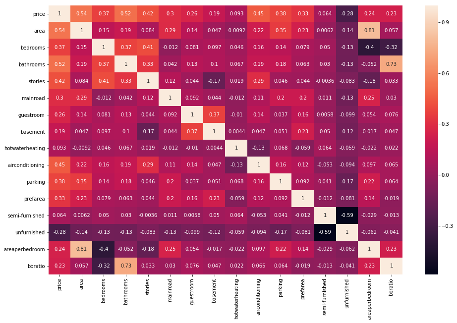

```python
plt.figure(figsize = (16,10))
sb.heatmap(house_d.corr(), annot = True)
plt.show()
```

### Splitting Data into Training & Testing Sets

```python
house_d.columns
```

```
Index(['price', 'area', 'bedrooms', 'bathrooms', 'stories', 'mainroad',
       'guestroom', 'basement', 'hotwaterheating', 'airconditioning',
       'parking', 'prefarea', 'semi-furnished', 'unfurnished',
       'areaperbedroom', 'bbratio'],
      dtype='object')
```

```python
house_d.shape
```

```
(545, 16)
```

```python
# putting all feature variables into x
x = house_d[['area', 'bedrooms', 'bathrooms', 'stories', 'mainroad', 'guestroom', 'basement', 'hotwaterheating', 'airconditioning',
             'parking', 'prefarea', 'semi-furnished', 'unfurnished', 'areaperbedroom', 'bbratio']]

# putting responce variable into y
y = house_d['price']
```

```python
x.head()
```

|  | area | bedrooms | bathrooms | stories | mainroad | guestroom | basement | hotwaterheating | airconditioning | parking | prefarea | semi-furnished | unfurnished | areaperbedroom | bbratio |
| --- | --- | --- | --- | --- | --- | --- | --- | --- | --- | --- | --- | --- | --- | --- | --- |
| 0 | 0.396564 | 0.6 | 0.333333 | 0.666667 | 1.0 | 0.0 | 0.0 | 0.0 | 1.0 | 0.666667 | 1.0 | 0.0 | 0.0 | 0.237016 | 0.4 |
| 1 | 0.502405 | 0.6 | 1.000000 | 1.000000 | 1.0 | 0.0 | 0.0 | 0.0 | 1.0 | 1.000000 | 0.0 | 0.0 | 0.0 | 0.298923 | 1.0 |
| 2 | 0.571134 | 0.4 | 0.333333 | 0.333333 | 1.0 | 0.0 | 1.0 | 0.0 | 0.0 | 0.666667 | 1.0 | 1.0 | 0.0 | 0.472584 | 0.6 |
| 3 | 0.402062 | 0.6 | 0.333333 | 0.333333 | 1.0 | 0.0 | 1.0 | 0.0 | 1.0 | 1.000000 | 1.0 | 0.0 | 0.0 | 0.240232 | 0.4 |
| 4 | 0.396564 | 0.6 | 0.000000 | 0.333333 | 1.0 | 1.0 | 1.0 | 0.0 | 1.0 | 0.666667 | 0.0 | 0.0 | 0.0 | 0.237016 | 0.1 |

```python
y.head()
```

```
0    1.000000
1    0.909091
2    0.909091
3    0.906061
4    0.836364
Name: price, dtype: float64
```

```python
from sklearn.model_selection import train_test_split as tts
```

```python
# random state is the seed used by the random number generator, it can be any integer.
x_train, x_test, y_train, y_test = tts(x, y, train_size = .7, random_state = 100)
x_train.shape
```

```
c:\users\krishna mishra\appdata\local\programs\python\python37-32\lib\site-packages\sklearn\model_selection\_split.py:2179: FutureWarning: From version 0.21, test_size will always complement train_size unless both are specified.
  FutureWarning)
```

```
(381, 15)
```

### Building Linear Model

```python
import statsmodels.api as sm
```

```python
x_train = sm.add_constant(x_train) # adding contant column to our df
# creating 1st fitted linear model
lm_1 = sm.OLS(y_train, x_train).fit()
lm_1.summary()
```

```
c:\users\krishna mishra\appdata\local\programs\python\python37-32\lib\site-packages\numpy\core\fromnumeric.py:2389: FutureWarning: Method .ptp is deprecated and will be removed in a future version. Use numpy.ptp instead.
  return ptp(axis=axis, out=out, **kwargs)
```

OLS Regression Results

| Dep. Variable: | price | R-squared: | 0.686 |
| --- | --- | --- | --- |
| Model: | OLS | Adj. R-squared: | 0.673 |
| Method: | Least Squares | F-statistic: | 53.12 |
| Date: | Tue, 19 Mar 2019 | Prob (F-statistic): | 4.56e-82 |
| Time: | 06:33:57 | Log-Likelihood: | 384.40 |
| No. Observations: | 381 | AIC: | -736.8 |
| Df Residuals: | 365 | BIC: | -673.7 |
| Df Model: | 15 |  |  |
| Covariance Type: | nonrobust |  |  |

|  | coef | std err | t | P>\|t\| | [0.025 | 0.975] |
| --- | --- | --- | --- | --- | --- | --- |
| const | 0.0603 | 0.059 | 1.029 | 0.304 | -0.055 | 0.176 |
| area | 0.5745 | 0.134 | 4.285 | 0.000 | 0.311 | 0.838 |
| bedrooms | -0.0587 | 0.093 | -0.632 | 0.528 | -0.241 | 0.124 |
| bathrooms | 0.2336 | 0.126 | 1.849 | 0.065 | -0.015 | 0.482 |
| stories | 0.1018 | 0.019 | 5.265 | 0.000 | 0.064 | 0.140 |
| mainroad | 0.0511 | 0.014 | 3.580 | 0.000 | 0.023 | 0.079 |
| guestroom | 0.0260 | 0.014 | 1.887 | 0.060 | -0.001 | 0.053 |
| basement | 0.0208 | 0.011 | 1.877 | 0.061 | -0.001 | 0.043 |
| hotwaterheating | 0.0875 | 0.022 | 4.048 | 0.000 | 0.045 | 0.130 |
| airconditioning | 0.0663 | 0.011 | 5.868 | 0.000 | 0.044 | 0.088 |
| parking | 0.0562 | 0.018 | 3.104 | 0.002 | 0.021 | 0.092 |
| prefarea | 0.0566 | 0.012 | 4.772 | 0.000 | 0.033 | 0.080 |
| semi-furnished | -0.0008 | 0.012 | -0.068 | 0.946 | -0.024 | 0.022 |
| unfurnished | -0.0323 | 0.013 | -2.550 | 0.011 | -0.057 | -0.007 |
| areaperbedroom | -0.3135 | 0.147 | -2.139 | 0.033 | -0.602 | -0.025 |
| bbratio | 0.0439 | 0.104 | 0.421 | 0.674 | -0.161 | 0.249 |

| Omnibus: | 87.283 | Durbin-Watson: | 2.087 |
| --- | --- | --- | --- |
| Prob(Omnibus): | 0.000 | Jarque-Bera (JB): | 276.328 |
| Skew: | 1.023 | Prob(JB): | 9.91e-61 |
| Kurtosis: | 6.636 | Cond. No. | 82.4 |

Warnings:  
[1] Standard Errors assume that the covariance matrix of the errors is correctly specified.

### Checking VIF

```python
# creating function for VIF calculation
def vif_cal(input_data, dependent_col):
    vif_df = pd.DataFrame(columns = ['var', 'vif'])
    x_vars = input_data.drop([dependent_col], axis = 1)
    xvar_names = x_vars.columns
    for i in range(0, xvar_names.shape[0]):
        y = x_vars[xvar_names[i]]
        x = x_vars[xvar_names.drop(xvar_names[i])]
        rsq = sm.OLS(y,x).fit().rsquared
        vif = round(1/(1-rsq),2)
        vif_df.loc[i] = [xvar_names[i], vif]
    return vif_df.sort_values(by = 'vif', axis = 0, ascending = False, inplace=False)
```

```python
# Calculating VIF values
vif_cal(input_data = house_d, dependent_col='price')
```

|  | var | vif |
| --- | --- | --- |
| 13 | areaperbedroom | 68.71 |
| 0 | area | 57.52 |
| 14 | bbratio | 29.25 |
| 2 | bathrooms | 11.11 |
| 1 | bedrooms | 10.68 |
| 4 | mainroad | 7.91 |
| 3 | stories | 2.81 |
| 11 | semi-furnished | 2.61 |
| 12 | unfurnished | 2.38 |
| 6 | basement | 2.05 |
| 9 | parking | 2.01 |
| 8 | airconditioning | 1.77 |
| 10 | prefarea | 1.51 |
| 5 | guestroom | 1.49 |
| 7 | hotwaterheating | 1.10 |

### Droping bbratio & updating the model

```python
# Droping Highly correlated & insignificant variables
x_train = x_train.drop('bbratio',1)
```

```python
# Creating 2nd fitted model
lm_2 = sm.OLS(y_train, x_train).fit()
lm_2.summary()
```

OLS Regression Results

| Dep. Variable: | price | R-squared: | 0.686 |
| --- | --- | --- | --- |
| Model: | OLS | Adj. R-squared: | 0.674 |
| Method: | Least Squares | F-statistic: | 57.03 |
| Date: | Tue, 19 Mar 2019 | Prob (F-statistic): | 6.46e-83 |
| Time: | 06:33:58 | Log-Likelihood: | 384.31 |
| No. Observations: | 381 | AIC: | -738.6 |
| Df Residuals: | 366 | BIC: | -679.5 |
| Df Model: | 14 |  |  |
| Covariance Type: | nonrobust |  |  |

|  | coef | std err | t | P>\|t\| | [0.025 | 0.975] |
| --- | --- | --- | --- | --- | --- | --- |
| const | 0.0799 | 0.036 | 2.239 | 0.026 | 0.010 | 0.150 |
| area | 0.5483 | 0.119 | 4.622 | 0.000 | 0.315 | 0.782 |
| bedrooms | -0.0845 | 0.070 | -1.209 | 0.227 | -0.222 | 0.053 |
| bathrooms | 0.2850 | 0.033 | 8.686 | 0.000 | 0.220 | 0.350 |
| stories | 0.1022 | 0.019 | 5.301 | 0.000 | 0.064 | 0.140 |
| mainroad | 0.0509 | 0.014 | 3.568 | 0.000 | 0.023 | 0.079 |
| guestroom | 0.0265 | 0.014 | 1.941 | 0.053 | -0.000 | 0.053 |
| basement | 0.0210 | 0.011 | 1.898 | 0.058 | -0.001 | 0.043 |
| hotwaterheating | 0.0866 | 0.021 | 4.031 | 0.000 | 0.044 | 0.129 |
| airconditioning | 0.0662 | 0.011 | 5.871 | 0.000 | 0.044 | 0.088 |
| parking | 0.0563 | 0.018 | 3.119 | 0.002 | 0.021 | 0.092 |
| prefarea | 0.0563 | 0.012 | 4.760 | 0.000 | 0.033 | 0.079 |
| semi-furnished | -0.0009 | 0.012 | -0.077 | 0.939 | -0.024 | 0.022 |
| unfurnished | -0.0323 | 0.013 | -2.554 | 0.011 | -0.057 | -0.007 |
| areaperbedroom | -0.2840 | 0.129 | -2.208 | 0.028 | -0.537 | -0.031 |

| Omnibus: | 88.466 | Durbin-Watson: | 2.085 |
| --- | --- | --- | --- |
| Prob(Omnibus): | 0.000 | Jarque-Bera (JB): | 282.794 |
| Skew: | 1.034 | Prob(JB): | 3.91e-62 |
| Kurtosis: | 6.679 | Cond. No. | 67.4 |

Warnings:  
[1] Standard Errors assume that the covariance matrix of the errors is correctly specified.

```python
# Calculating VIF values
vif_cal(input_data = house_d.drop(['bbratio'],axis = 1), dependent_col='price')
```

|  | var | vif |
| --- | --- | --- |
| 0 | area | 20.72 |
| 13 | areaperbedroom | 18.44 |
| 1 | bedrooms | 10.03 |
| 4 | mainroad | 7.46 |
| 3 | stories | 2.78 |
| 11 | semi-furnished | 2.48 |
| 12 | unfurnished | 2.20 |
| 6 | basement | 2.03 |
| 9 | parking | 2.00 |
| 8 | airconditioning | 1.77 |
| 2 | bathrooms | 1.71 |
| 10 | prefarea | 1.51 |
| 5 | guestroom | 1.48 |
| 7 | hotwaterheating | 1.09 |

### Droping bbratio, bedrooms Both & updating the model

```python
# Droping Highly correlated & insignificant variables
x_train = x_train.drop('bedrooms',1)
```

```python
# Creating 3rd fitted model
lm_3 = sm.OLS(y_train, x_train).fit()
lm_3.summary()
```

OLS Regression Results

| Dep. Variable: | price | R-squared: | 0.684 |
| --- | --- | --- | --- |
| Model: | OLS | Adj. R-squared: | 0.673 |
| Method: | Least Squares | F-statistic: | 61.23 |
| Date: | Tue, 19 Mar 2019 | Prob (F-statistic): | 1.66e-83 |
| Time: | 06:33:58 | Log-Likelihood: | 383.55 |
| No. Observations: | 381 | AIC: | -739.1 |
| Df Residuals: | 367 | BIC: | -683.9 |
| Df Model: | 13 |  |  |
| Covariance Type: | nonrobust |  |  |

|  | coef | std err | t | P>\|t\| | [0.025 | 0.975] |
| --- | --- | --- | --- | --- | --- | --- |
| const | 0.0427 | 0.018 | 2.362 | 0.019 | 0.007 | 0.078 |
| area | 0.4326 | 0.070 | 6.164 | 0.000 | 0.295 | 0.571 |
| bathrooms | 0.2814 | 0.033 | 8.606 | 0.000 | 0.217 | 0.346 |
| stories | 0.1005 | 0.019 | 5.224 | 0.000 | 0.063 | 0.138 |
| mainroad | 0.0515 | 0.014 | 3.611 | 0.000 | 0.023 | 0.080 |
| guestroom | 0.0285 | 0.014 | 2.101 | 0.036 | 0.002 | 0.055 |
| basement | 0.0201 | 0.011 | 1.822 | 0.069 | -0.002 | 0.042 |
| hotwaterheating | 0.0850 | 0.021 | 3.963 | 0.000 | 0.043 | 0.127 |
| airconditioning | 0.0667 | 0.011 | 5.909 | 0.000 | 0.044 | 0.089 |
| parking | 0.0573 | 0.018 | 3.175 | 0.002 | 0.022 | 0.093 |
| prefarea | 0.0576 | 0.012 | 4.895 | 0.000 | 0.034 | 0.081 |
| semi-furnished | 9.202e-06 | 0.012 | 0.001 | 0.999 | -0.023 | 0.023 |
| unfurnished | -0.0313 | 0.013 | -2.478 | 0.014 | -0.056 | -0.006 |
| areaperbedroom | -0.1516 | 0.068 | -2.242 | 0.026 | -0.285 | -0.019 |

| Omnibus: | 88.924 | Durbin-Watson: | 2.085 |
| --- | --- | --- | --- |
| Prob(Omnibus): | 0.000 | Jarque-Bera (JB): | 283.140 |
| Skew: | 1.041 | Prob(JB): | 3.29e-62 |
| Kurtosis: | 6.674 | Cond. No. | 33.3 |

Warnings:  
[1] Standard Errors assume that the covariance matrix of the errors is correctly specified.

```python
# Calculating VIF values
vif_cal(input_data = house_d.drop(['bbratio','bedrooms'],axis = 1), dependent_col='price')
```

|  | var | vif |
| --- | --- | --- |
| 0 | area | 14.98 |
| 12 | areaperbedroom | 13.88 |
| 3 | mainroad | 6.10 |
| 2 | stories | 2.56 |
| 10 | semi-furnished | 2.04 |
| 8 | parking | 2.00 |
| 5 | basement | 1.90 |
| 7 | airconditioning | 1.76 |
| 11 | unfurnished | 1.72 |
| 1 | bathrooms | 1.69 |
| 9 | prefarea | 1.50 |
| 4 | guestroom | 1.48 |
| 6 | hotwaterheating | 1.09 |

### Droping bbratio, bedrooms, areaperbedroom & updating the model

```python
# Droping Highly correlated & insignificant variables
x_train = x_train.drop('areaperbedroom',1)
```

```python
# Creating 4th fitted model
lm_4 = sm.OLS(y_train, x_train).fit()
lm_4.summary()
```

OLS Regression Results

| Dep. Variable: | price | R-squared: | 0.680 |
| --- | --- | --- | --- |
| Model: | OLS | Adj. R-squared: | 0.670 |
| Method: | Least Squares | F-statistic: | 65.20 |
| Date: | Tue, 19 Mar 2019 | Prob (F-statistic): | 2.35e-83 |
| Time: | 06:33:59 | Log-Likelihood: | 380.96 |
| No. Observations: | 381 | AIC: | -735.9 |
| Df Residuals: | 368 | BIC: | -684.7 |
| Df Model: | 12 |  |  |
| Covariance Type: | nonrobust |  |  |

|  | coef | std err | t | P>\|t\| | [0.025 | 0.975] |
| --- | --- | --- | --- | --- | --- | --- |
| const | 0.0313 | 0.017 | 1.795 | 0.074 | -0.003 | 0.066 |
| area | 0.3008 | 0.039 | 7.799 | 0.000 | 0.225 | 0.377 |
| bathrooms | 0.2947 | 0.032 | 9.114 | 0.000 | 0.231 | 0.358 |
| stories | 0.1178 | 0.018 | 6.643 | 0.000 | 0.083 | 0.153 |
| mainroad | 0.0488 | 0.014 | 3.419 | 0.001 | 0.021 | 0.077 |
| guestroom | 0.0301 | 0.014 | 2.207 | 0.028 | 0.003 | 0.057 |
| basement | 0.0239 | 0.011 | 2.179 | 0.030 | 0.002 | 0.045 |
| hotwaterheating | 0.0864 | 0.022 | 4.007 | 0.000 | 0.044 | 0.129 |
| airconditioning | 0.0666 | 0.011 | 5.870 | 0.000 | 0.044 | 0.089 |
| parking | 0.0629 | 0.018 | 3.495 | 0.001 | 0.027 | 0.098 |
| prefarea | 0.0597 | 0.012 | 5.055 | 0.000 | 0.036 | 0.083 |
| semi-furnished | 0.0008 | 0.012 | 0.067 | 0.947 | -0.022 | 0.024 |
| unfurnished | -0.0318 | 0.013 | -2.504 | 0.013 | -0.057 | -0.007 |

| Omnibus: | 97.809 | Durbin-Watson: | 2.097 |
| --- | --- | --- | --- |
| Prob(Omnibus): | 0.000 | Jarque-Bera (JB): | 326.485 |
| Skew: | 1.131 | Prob(JB): | 1.27e-71 |
| Kurtosis: | 6.930 | Cond. No. | 13.9 |

Warnings:  
[1] Standard Errors assume that the covariance matrix of the errors is correctly specified.

```python
# Calculating VIF values
vif_cal(input_data = house_d.drop(['bbratio','bedrooms','areaperbedroom'],axis = 1), dependent_col='price')
```

|  | var | vif |
| --- | --- | --- |
| 3 | mainroad | 5.51 |
| 0 | area | 4.43 |
| 2 | stories | 2.32 |
| 10 | semi-furnished | 2.00 |
| 8 | parking | 1.99 |
| 5 | basement | 1.90 |
| 7 | airconditioning | 1.76 |
| 11 | unfurnished | 1.65 |
| 1 | bathrooms | 1.62 |
| 9 | prefarea | 1.50 |
| 4 | guestroom | 1.47 |
| 6 | hotwaterheating | 1.09 |

##### Since semi furnished is still not significant. so, let's remove it

### Droping bbratio, bedrooms, areaperbedroom, semi-furnished & updating the model

```python
# Droping Highly correlated & insignificant variables
x_train = x_train.drop('semi-furnished',1)
```

```python
# Creating 5th fitted model
lm_5 = sm.OLS(y_train, x_train).fit()
lm_5.summary()
```

OLS Regression Results

| Dep. Variable: | price | R-squared: | 0.680 |
| --- | --- | --- | --- |
| Model: | OLS | Adj. R-squared: | 0.671 |
| Method: | Least Squares | F-statistic: | 71.31 |
| Date: | Tue, 19 Mar 2019 | Prob (F-statistic): | 2.73e-84 |
| Time: | 06:33:59 | Log-Likelihood: | 380.96 |
| No. Observations: | 381 | AIC: | -737.9 |
| Df Residuals: | 369 | BIC: | -690.6 |
| Df Model: | 11 |  |  |
| Covariance Type: | nonrobust |  |  |

|  | coef | std err | t | P>\|t\| | [0.025 | 0.975] |
| --- | --- | --- | --- | --- | --- | --- |
| const | 0.0319 | 0.015 | 2.142 | 0.033 | 0.003 | 0.061 |
| area | 0.3006 | 0.038 | 7.851 | 0.000 | 0.225 | 0.376 |
| bathrooms | 0.2947 | 0.032 | 9.132 | 0.000 | 0.231 | 0.358 |
| stories | 0.1178 | 0.018 | 6.654 | 0.000 | 0.083 | 0.153 |
| mainroad | 0.0488 | 0.014 | 3.423 | 0.001 | 0.021 | 0.077 |
| guestroom | 0.0301 | 0.014 | 2.211 | 0.028 | 0.003 | 0.057 |
| basement | 0.0239 | 0.011 | 2.183 | 0.030 | 0.002 | 0.045 |
| hotwaterheating | 0.0864 | 0.022 | 4.014 | 0.000 | 0.044 | 0.129 |
| airconditioning | 0.0665 | 0.011 | 5.895 | 0.000 | 0.044 | 0.089 |
| parking | 0.0629 | 0.018 | 3.501 | 0.001 | 0.028 | 0.098 |
| prefarea | 0.0596 | 0.012 | 5.061 | 0.000 | 0.036 | 0.083 |
| unfurnished | -0.0323 | 0.010 | -3.169 | 0.002 | -0.052 | -0.012 |

| Omnibus: | 97.661 | Durbin-Watson: | 2.097 |
| --- | --- | --- | --- |
| Prob(Omnibus): | 0.000 | Jarque-Bera (JB): | 325.388 |
| Skew: | 1.130 | Prob(JB): | 2.20e-71 |
| Kurtosis: | 6.923 | Cond. No. | 13.3 |

Warnings:  
[1] Standard Errors assume that the covariance matrix of the errors is correctly specified.

```python
# Calculating VIF values
vif_cal(input_data = house_d.drop(['bbratio','bedrooms','areaperbedroom','semi-furnished'],axis = 1), dependent_col='price')
```

|  | var | vif |
| --- | --- | --- |
| 3 | mainroad | 4.85 |
| 0 | area | 4.36 |
| 2 | stories | 2.30 |
| 8 | parking | 1.99 |
| 5 | basement | 1.86 |
| 7 | airconditioning | 1.75 |
| 1 | bathrooms | 1.62 |
| 9 | prefarea | 1.49 |
| 4 | guestroom | 1.47 |
| 10 | unfurnished | 1.34 |
| 6 | hotwaterheating | 1.08 |

### Droping bbratio, bedrooms, areaperbedroom, semi-furnished, basement & updating the model

```python
# Droping Highly correlated & insignificant variables
x_train = x_train.drop('basement',1)
```

```python
# Creating 6th fitted model
lm_6 = sm.OLS(y_train, x_train).fit()
lm_6.summary()
```

OLS Regression Results

| Dep. Variable: | price | R-squared: | 0.676 |
| --- | --- | --- | --- |
| Model: | OLS | Adj. R-squared: | 0.667 |
| Method: | Least Squares | F-statistic: | 77.18 |
| Date: | Tue, 19 Mar 2019 | Prob (F-statistic): | 3.13e-84 |
| Time: | 06:34:00 | Log-Likelihood: | 378.51 |
| No. Observations: | 381 | AIC: | -735.0 |
| Df Residuals: | 370 | BIC: | -691.7 |
| Df Model: | 10 |  |  |
| Covariance Type: | nonrobust |  |  |

|  | coef | std err | t | P>\|t\| | [0.025 | 0.975] |
| --- | --- | --- | --- | --- | --- | --- |
| const | 0.0390 | 0.015 | 2.670 | 0.008 | 0.010 | 0.068 |
| area | 0.2990 | 0.038 | 7.772 | 0.000 | 0.223 | 0.375 |
| bathrooms | 0.3028 | 0.032 | 9.397 | 0.000 | 0.239 | 0.366 |
| stories | 0.1081 | 0.017 | 6.277 | 0.000 | 0.074 | 0.142 |
| mainroad | 0.0497 | 0.014 | 3.468 | 0.001 | 0.022 | 0.078 |
| guestroom | 0.0402 | 0.013 | 3.124 | 0.002 | 0.015 | 0.065 |
| hotwaterheating | 0.0876 | 0.022 | 4.051 | 0.000 | 0.045 | 0.130 |
| airconditioning | 0.0682 | 0.011 | 6.028 | 0.000 | 0.046 | 0.090 |
| parking | 0.0629 | 0.018 | 3.482 | 0.001 | 0.027 | 0.098 |
| prefarea | 0.0637 | 0.012 | 5.452 | 0.000 | 0.041 | 0.087 |
| unfurnished | -0.0337 | 0.010 | -3.295 | 0.001 | -0.054 | -0.014 |

| Omnibus: | 97.054 | Durbin-Watson: | 2.099 |
| --- | --- | --- | --- |
| Prob(Omnibus): | 0.000 | Jarque-Bera (JB): | 322.034 |
| Skew: | 1.124 | Prob(JB): | 1.18e-70 |
| Kurtosis: | 6.902 | Cond. No. | 12.9 |

Warnings:  
[1] Standard Errors assume that the covariance matrix of the errors is correctly specified.

```python
# Calculating VIF values
vif_cal(input_data = house_d.drop(['bbratio','bedrooms','areaperbedroom','semi-furnished','basement'],axis = 1), dependent_col='price')
```

|  | var | vif |
| --- | --- | --- |
| 3 | mainroad | 4.58 |
| 0 | area | 4.36 |
| 2 | stories | 2.21 |
| 7 | parking | 1.99 |
| 6 | airconditioning | 1.75 |
| 1 | bathrooms | 1.59 |
| 8 | prefarea | 1.44 |
| 9 | unfurnished | 1.34 |
| 4 | guestroom | 1.29 |
| 5 | hotwaterheating | 1.08 |

### Making Predictions using the Final Model

#### Prediction with Model 6

```python
# Adding constant variable to test dataframe
x_test_m6 = sm.add_constant(x_test)
```

```python
# Creating x_test_m6 dataframe by dropping variables from x_test_m6
x_test_m6 = x_test_m6.drop(['bbratio','bedrooms','areaperbedroom','semi-furnished','basement'],axis = 1)
```

```python
# Making Predictions
y_pred_m6 = lm_6.predict(x_test_m6)
```

### Model Evaluation

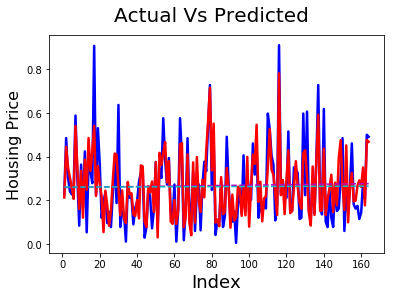

```python
# Actual Vs Predicted
c = [i for i in range(1,165,1)]
fig = plt.figure
plt.plot(c, y_test, color = 'blue', linewidth = 2.5, linestyle = '-') # plotting Actual
plt.plot(c, y_pred_m6, color = 'red', linewidth = 2.5, linestyle = '-') # plotting Actual
z1 = np.polyfit(c, y_pred_m6, 1)
p1 = np.poly1d(z1)
plt.plot(c,p1(c),"m--")
z2 = np.polyfit(c, y_test, 1)
p2 = np.poly1d(z2)
plt.plot(c,p2(c),"c--")
plt.suptitle('Actual Vs Predicted', fontsize = 20)
plt.xlabel('Index', fontsize = 18)
plt.ylabel('Housing Price', fontsize = 16)
plt.show()
```

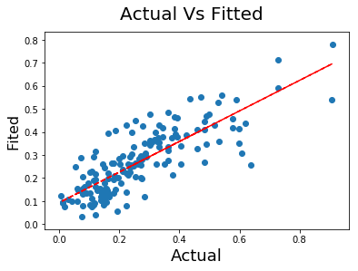

```python
# plotting y_test & y_pred to understand spread.
fig = plt.figure
plt.scatter(y_test, y_pred_m6)
z = np.polyfit(y_test, y_pred_m6, 1)
p = np.poly1d(z)
plt.plot(y_test,p(y_test),"r--")
plt.suptitle('Actual Vs Fitted', fontsize = 20)
plt.xlabel('Actual', fontsize = 18)
plt.ylabel('Fited', fontsize = 16)
plt.show()
```

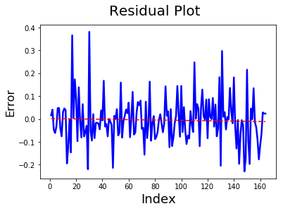

```python
# Residual Plot
c = [i for i in range(1,165,1)]
fig = plt.figure
plt.plot(c, y_test-y_pred_m6, color = 'blue', linewidth = 2.5, linestyle = '-')
z = np.polyfit(c, y_test-y_pred_m6, 1)
p = np.poly1d(z)
plt.plot(c,p(c),"r--")
plt.suptitle('Residual Plot', fontsize = 20)
plt.xlabel('Index', fontsize = 18)
plt.ylabel('Error', fontsize = 16)
plt.show()
```

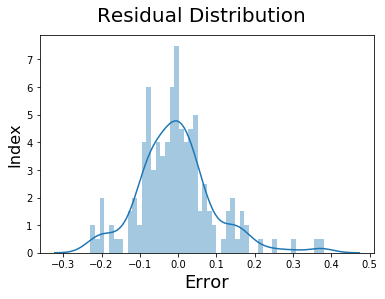

```python
# Plotting Residual to understand the Distribution.
fig = plt.figure()
sb.distplot(y_test-y_pred_m6, bins=50)
plt.suptitle('Residual Distribution', fontsize = 20)
plt.xlabel('Error', fontsize = 18)
plt.ylabel('Index', fontsize = 16)
plt.show()
```

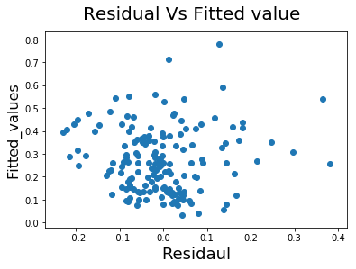

```python
# Residual Vs Fitted Value/Predicted value.
fig = plt.figure
plt.scatter(y_test-y_pred_m6, y_pred_m6)
plt.suptitle('Residual Vs Fitted value', fontsize = 20)
plt.xlabel('Residaul', fontsize = 18)
plt.ylabel('Fitted_values', fontsize = 16)
plt.show()
```

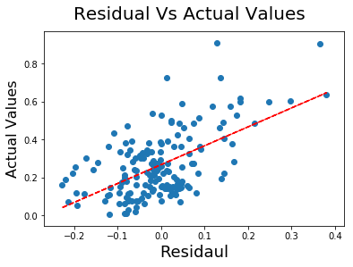

```python
# Residual Vs Actual Values.
fig = plt.figure
plt.scatter(y_test-y_pred_m6, y_test)
z = np.polyfit(y_test-y_pred_m6, y_test, 1)
p = np.poly1d(z)
plt.plot(y_test-y_pred_m6,p(y_test-y_pred_m6),"r--")
plt.suptitle('Residual Vs Actual Values', fontsize = 20)
plt.xlabel('Residaul', fontsize = 18)
plt.ylabel('Actual Values', fontsize = 16)
plt.show()
```

```python
import numpy as np
from sklearn import metrics
print('RMSE:     ', np.sqrt(metrics.mean_squared_error(y_test, y_pred_m6)))
print('Adj. R^2: ', 0.667)
```

```
RMSE:      0.10001092336807833
Adj. R^2:  0.667
```